# Introduction

La loi normale est très utilisée en sciences dures et en sciences sociales pour représenter les valeurs d'une variable aléatoire. Il s'agit d'une loi continue de probabilité.

# Loi normale : notations

## $X \sim N(\mu,\sigma^2)$

### $\mu$ : la moyenne

### $\sigma$ : l'écart-type

# Densité de la loi normale.

## $ f(x)=\frac{1}{\sigma \sqrt{2 \pi}}e^{-\frac{(x- \mu)^2}{2 \sigma^2}} $

# Aire sous la courbe

## $ \int \limits _{-\infty} ^{+\infty}f(x)dx=1 \text{ (l'aire sous la courbe vaut 1)} $

# La Loi normale centrée réduite

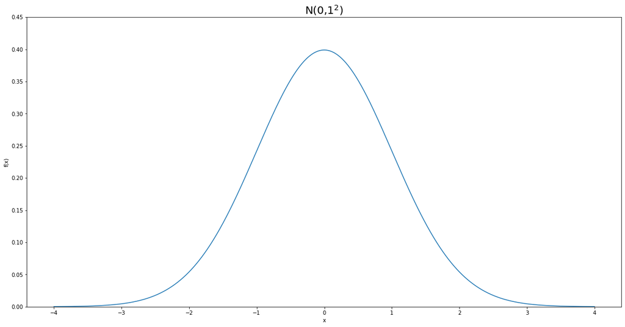

# Lire la valeur de la fonction de densité

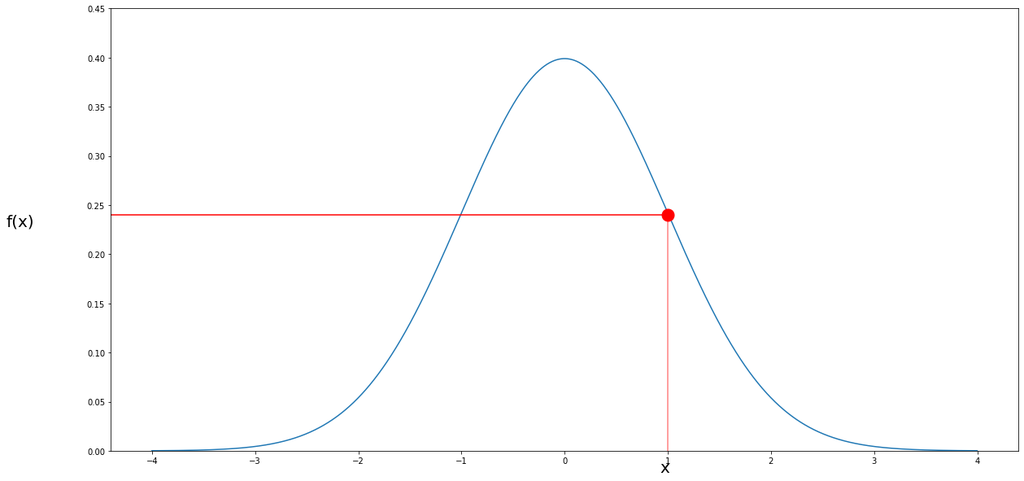

# Influence de l'écart-type (ou paramètre d'échelle)

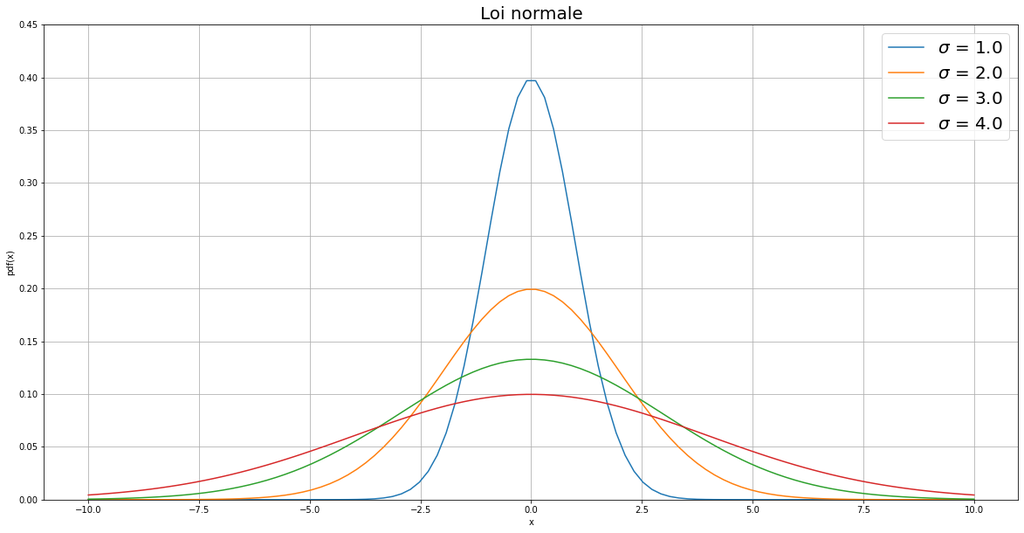

# Influence de la moyenne (ou paramètre de localisation

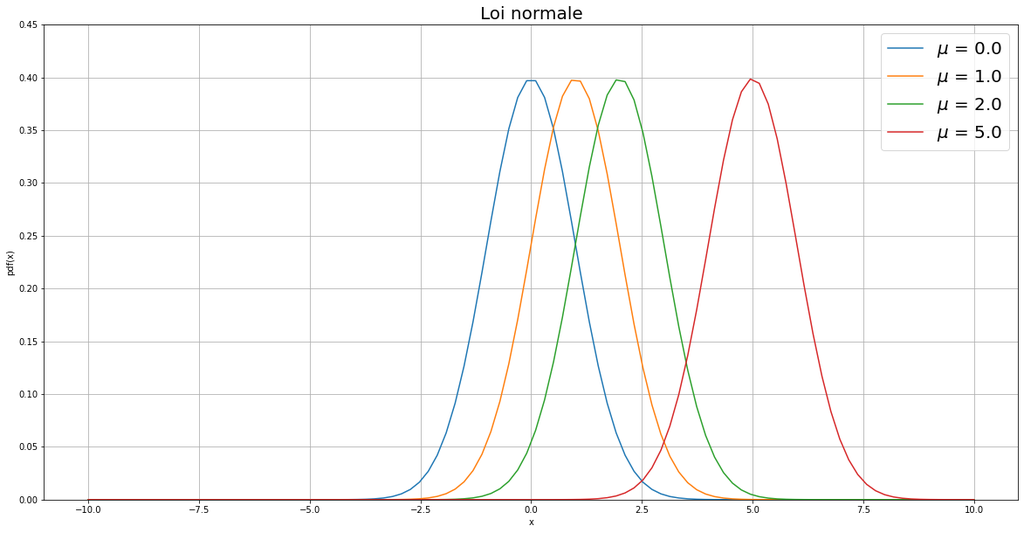

The mean of the distribution determines the location of the center of the graph. As you can see in the above graph, the shape of the graph does not change by changing the mean, but the graph is translated horizontally.

# Générer selon cette loi et comparer à la loi

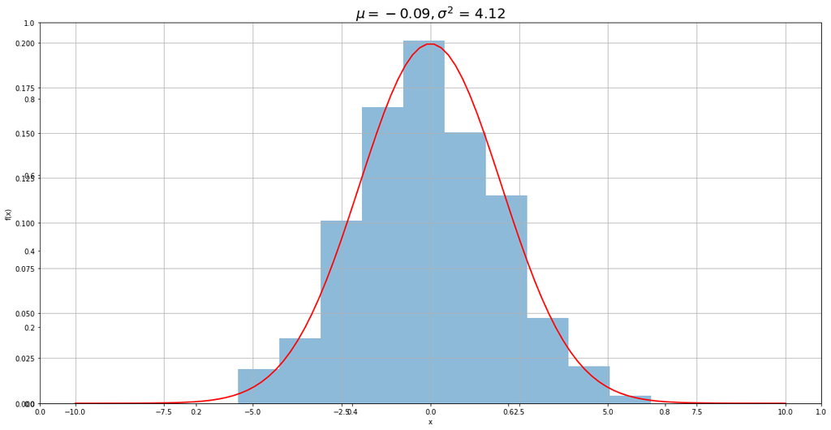

# Probabilité et aire sous la courbe

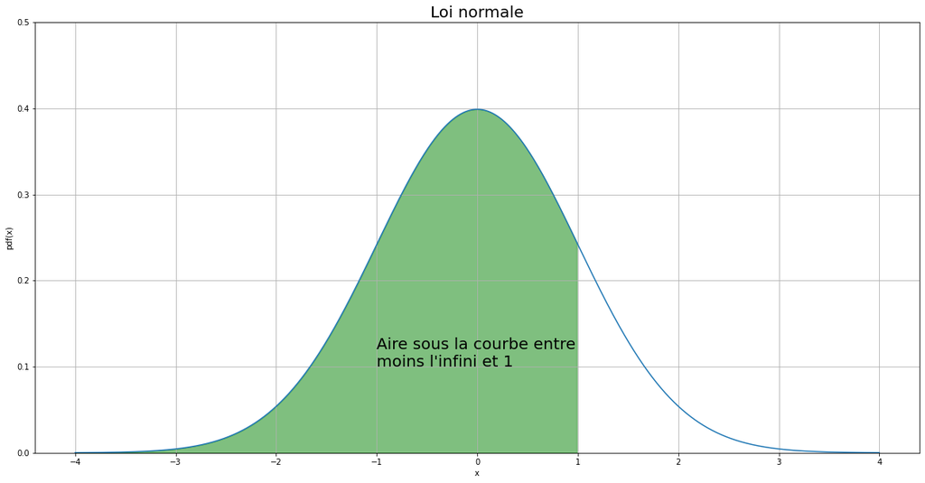

# Calculer la probabilité pour une distribution normale

## $X \sim N(3,2^2)$

## On calcule $\mathbb{P}(X \leq 2)$

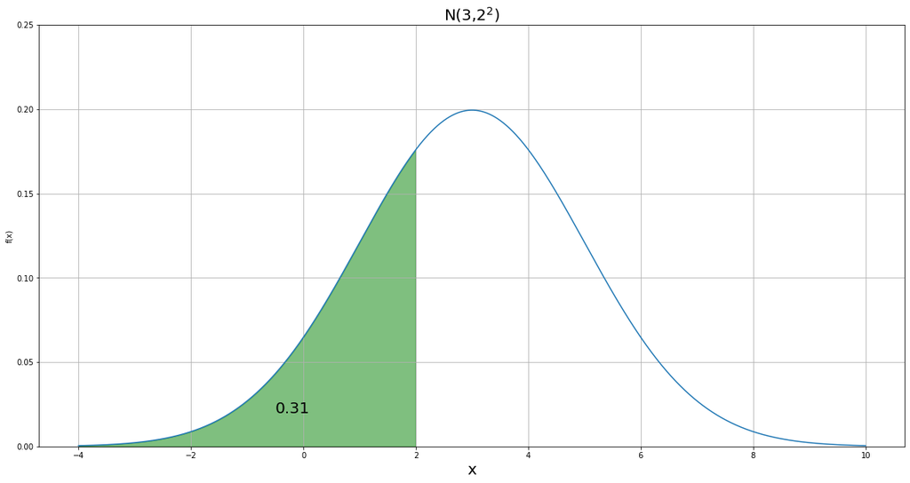

# Calculer la probabilité pour une distribution normale

## $X \sim N(1,2^2)$

## On calcule $\mathbb{P}(0.5 \leq X \leq 2)$

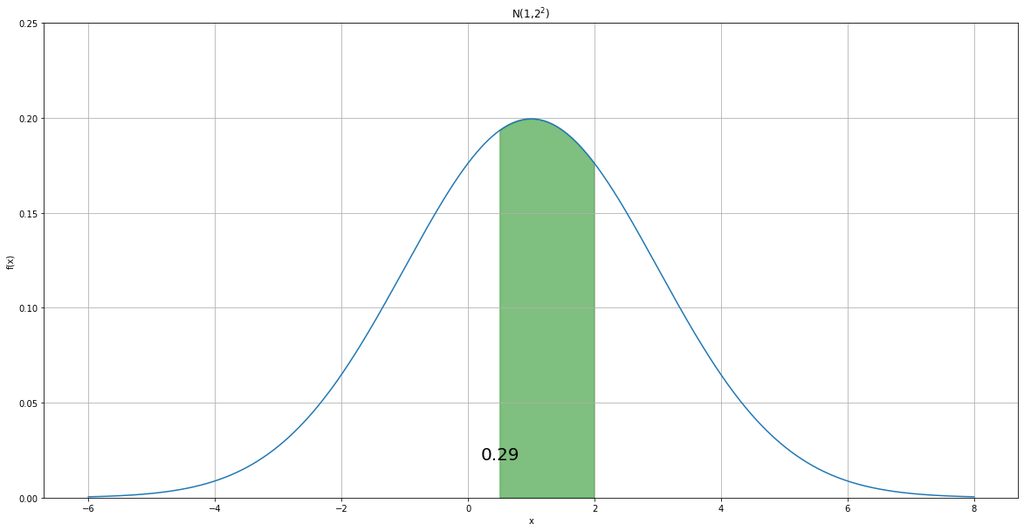

# Calculer la probabilité pour une distribution normale

## $X \sim N(3,2^2)$

## On calcule $\mathbb{P}(4 \leq X)$

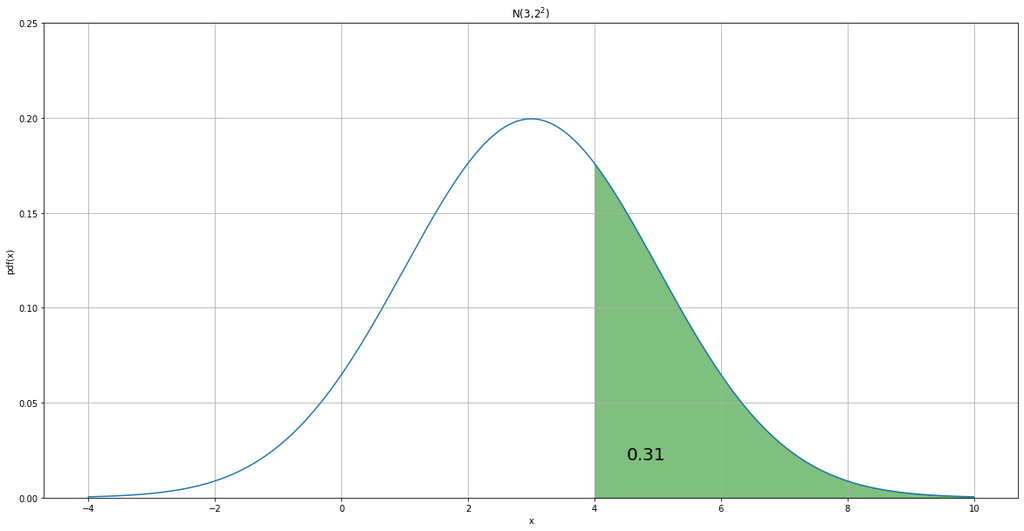

# Calculer la probabilité pour une distribution normale

## $$X \sim N(3,2^2)$$

## On calcule $\mathbb{P}(4 \leq X)$ et $\mathbb{P}(\overline{4 \leq X}) =\mathbb{P}(4 \geq X) $

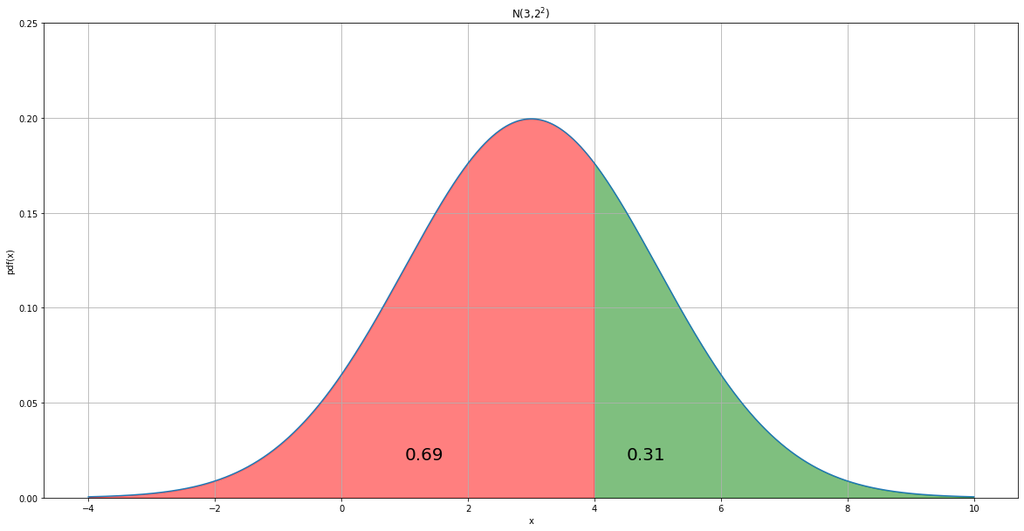

# Trouver les quantiles

## Le quantile d'ordre 95 % est définie comme la valeur $q_{0.95}$ qui vérifie :

## $P(X \leq q_{0.95})=0.95$

## De même, le quantile d'ordre p est définie comme la valeur $q_{p}$ qui vérifie :

## $P(X \leq q_{p})= p$

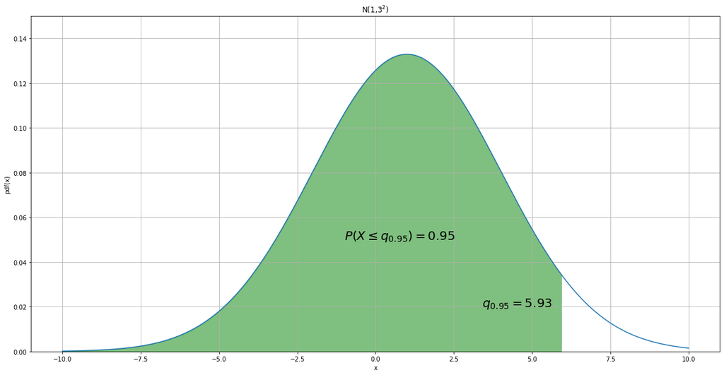

# Intervalles autour de la moyenne

## $X \sim N(0,1^2)$

[figure not shown]

```python
fig, ax = plt.subplots(figsize=(20,10))
x= np.arange(-4,4,0.001)
ax.plot(x, norm.pdf(x))
ax.set_title("Interval autour de la moyenne $\mu = 0$", fontsize=20)
ax.set_xlabel('x')
ax.set_ylabel('pdf(x)')
ax.grid(True)

px=np.arange(-4,4,0.01)
ax.set_ylim(0,0.5)
ax.fill_between(px,norm.pdf(px),alpha=0.5, color='g')

ax.text(-0.5,0.3,"Aire = 0.95", fontsize=20)
ax.text(1.96, 0.1,"$q_{0.975} = 1.96$", fontsize=20)
ax.text(-1.96, 0.1,"$q_{0.025} = - 1.96$", fontsize=20)
plt.show()
```

# Un exemple de loi normale multivariée

## On a ici deux variables aléatoires $X$ et $Y$ :

## $X \sim N(1,1^2)$

## $Y \sim N(2, 2^2)$

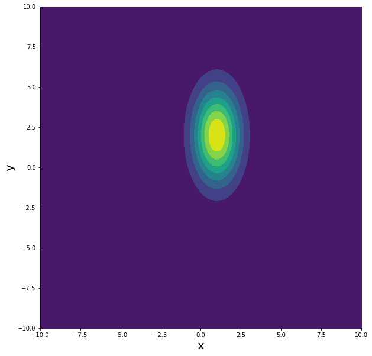

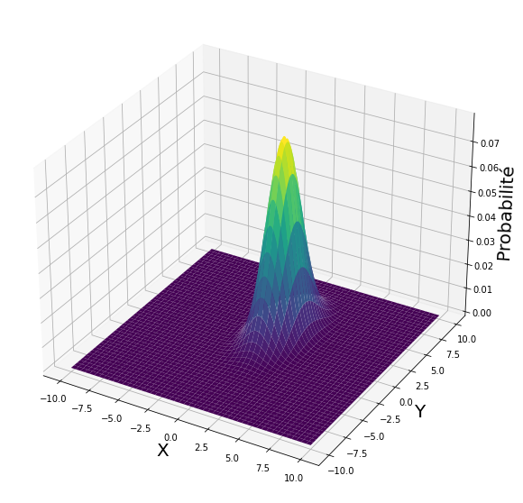

# Distribution normale centrée réduite

## Si $\mu=0$ $\sigma=1$, on parle de loi normale centrée réduite

## Sa densité est : $ \Phi(x)=\frac{1}{\sqrt{2\pi}}e^{\frac{-x^2}{2}}$

# Centrer et réduire une loi normale

## On peut centrer et réduire $X \sim N(\mu, \sigma^2)$ en $Z \sim N(0,1)$ en calculant : $ Z=\frac{X-\mu}{\sigma} $